# Assignment3_B_1_2

Sangamesh

26 September 2018

Reading data and making data into training and test data.

```
## [1] "head of training data"
```

```
##         Y1          X1        X2 X3
## 1 4.327805  1.33515849 0.4730140  6
## 2 8.139683 17.33750408 0.3195393  7
## 3 3.193994  6.79640276 0.3452665  3
## 4 1.869722  0.08149526 0.1059610  3
## 5 6.148741  2.87826189 0.2465312  8
## 6 7.611793  6.02848032 0.2045437  9
```

```
## [1] "head of testing data"
```

```
##            Y1         X1         X2 X3
## 10 5.36699195   4.395668 0.84454209  7
## 20 2.15690801  -5.920465 0.11914961  5
## 30 3.07860126 -12.195155 0.05738101  8
## 40 0.98051223  -1.257590 0.21801173  2
## 50 0.09861866  -2.467828 0.26064943  1
## 60 4.70909399   7.368437 0.20267976  5
```

Fitting data for linear regression model

```
##
## Call:
## lm(formula = Y1 ~ X1 + X2 + X3, data = trainData)
##
## Residuals:
##      Min       1Q   Median       3Q      Max
## -0.21901 -0.06800 -0.01703  0.07815  0.28281
##
## Coefficients:
##              Estimate Std. Error t value Pr(>|t|)
## (Intercept) -0.037081   0.027754  -1.336    0.185
## X1           0.201507   0.002523  79.857   <2e-16 ***
## X2          -0.454286   0.038373 -11.839   <2e-16 ***
## X3           0.705114   0.003951 178.466   <2e-16 ***
## ---
## Signif. codes:  0 '***' 0.001 '**' 0.01 '*' 0.05 '.' 0.1 ' ' 1
##
## Residual standard error: 0.1068 on 86 degrees of freedom
## Multiple R-squared:  0.9977, Adjusted R-squared:  0.9976
## F-statistic: 1.219e+04 on 3 and 86 DF,  p-value: < 2.2e-16
```

Several metrics useful for regression diagnostics : model.diag.metrics

| .rownames | Y1 | X1 | X2 | X3 | .fitted | .se.fit | .resid | .hat | .sigma | .cooksd | .std.resid |
| --- | --- | --- | --- | --- | --- | --- | --- | --- | --- | --- | --- |
| 1 | 4.327805 | 1.33515849 | 0.4730140 | 6 | 4.247766 | 0.01400693 | 0.08003927 | 0.01719109 | 0.1070987 | 0.002497633 | 0.7557483 |
| 2 | 8.139683 | 17.33750408 | 0.3195393 | 7 | 8.247182 | 0.04331971 | -0.10749956 | 0.16443269 | 0.1066963 | 0.059620533 | -1.1008409 |
| 3 | 3.193994 | 6.79640276 | 0.3452665 | 3 | 3.290934 | 0.01733265 | -0.09694008 | 0.02632372 | 0.1069265 | 0.005715865 | -0.9196121 |
| 4 | 1.869722 | 0.08149526 | 0.1059610 | 3 | 2.046548 | 0.01938387 | -0.17682550 | 0.03292291 | 0.1056714 | 0.024111430 | -1.6831504 |
| 5 | 6.148741 | 2.87826189 | 0.2465312 | 8 | 6.071829 | 0.02147577 | 0.07691228 | 0.04041240 | 0.1071181 | 0.005687140 | 0.7349571 |
| 6 | 7.611793 | 6.02848032 | 0.2045437 | 9 | 7.430808 | 0.02737526 | 0.18098504 | 0.06566498 | 0.1055196 | 0.053972320 | 1.7526692 |

Meta Data for model.diag.metrics Among the table columns, there are:

Y1: original values X1, X2: the observed values .fitted: the fitted values .resid: the residual errors

We can see the plot in residual and fitted plot here now:

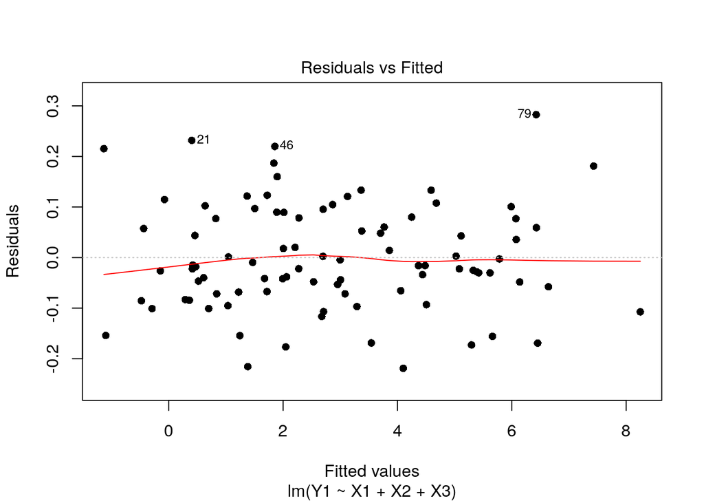

Note how the residuals plot of this last model shows some important points still lying far away from the middle area of the graph. Since the behaviour is random in nature we were successful in this test.

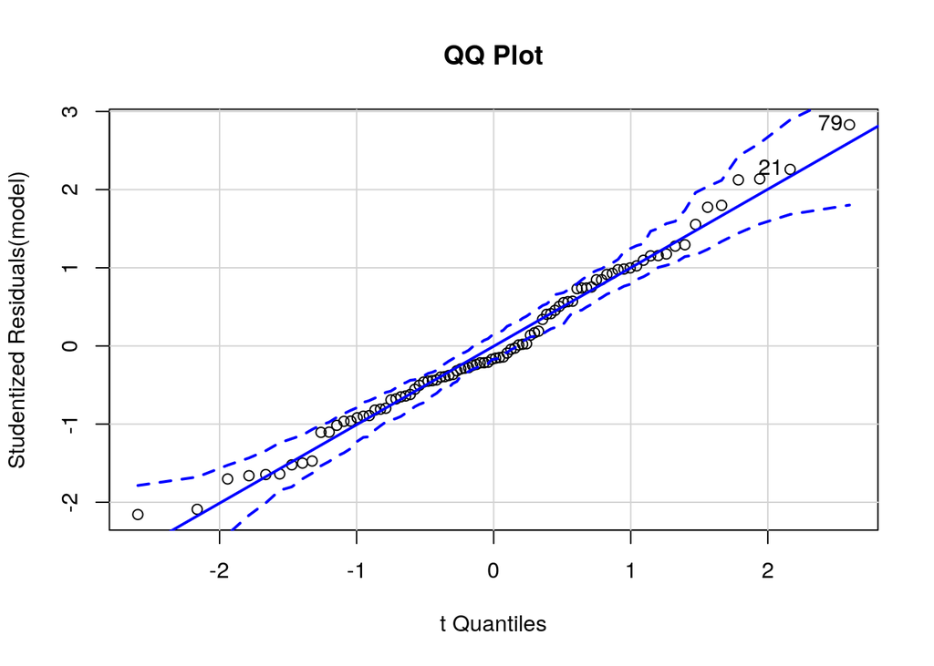

```
## 21 79
## 19 72
```

Check outliers:

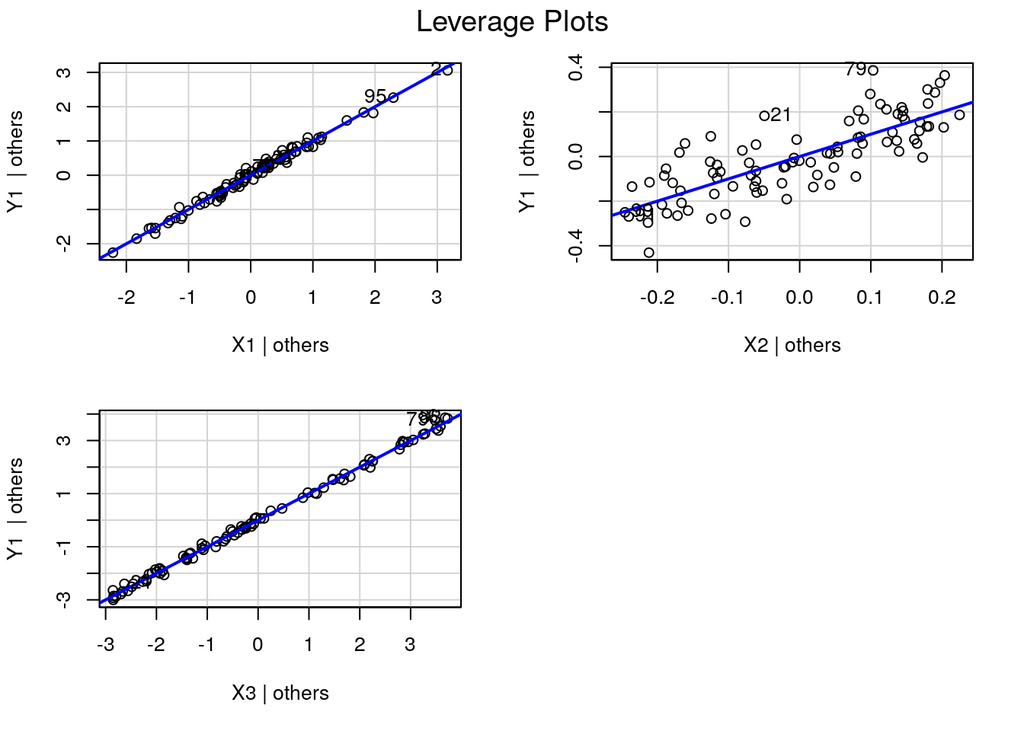

Check if errors are auto corelated

```
##
##  Durbin-Watson test
##
## data:  model
## DW = 2.2712, p-value = 0.9044
## alternative hypothesis: true autocorrelation is greater than 0
```

Influential Variables : Fiding influential data points is required. So let us look at variable plots:

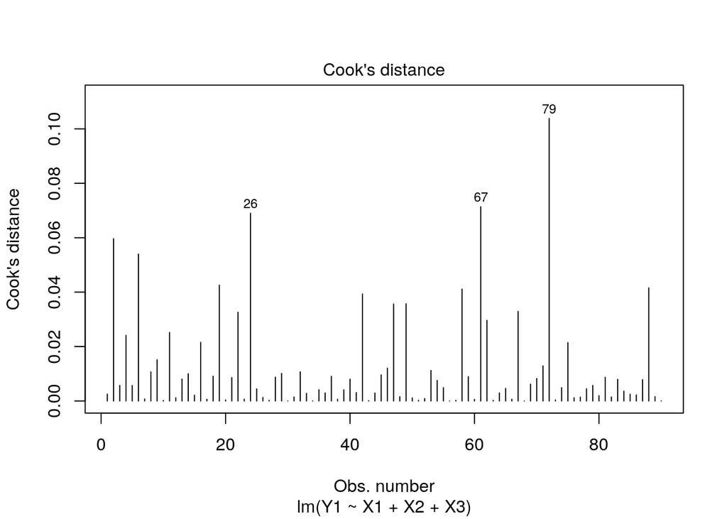

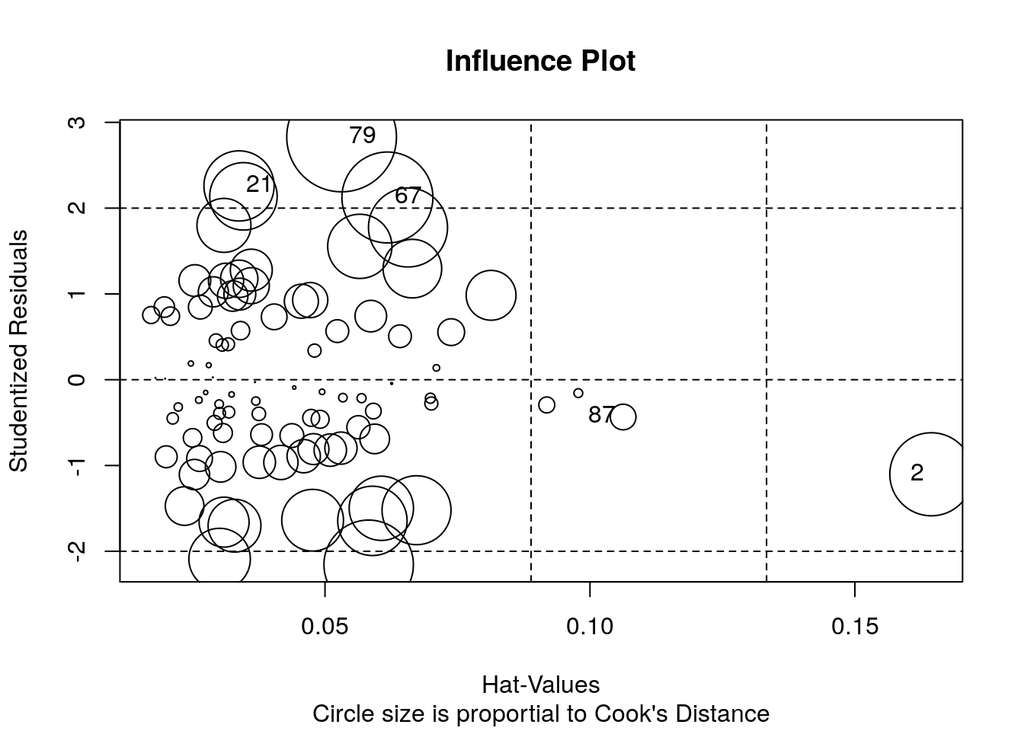

|  | StudRes | Hat | CookD |
| --- | --- | --- | --- |
| 2 | -1.1022153 | 0.16443269 | 0.059620533 |
| 21 | 2.2588599 | 0.03377374 | 0.042557952 |
| 67 | 2.1243499 | 0.06177616 | 0.071370638 |
| 79 | 2.8291379 | 0.05313276 | 0.103828905 |
| 87 | -0.4347168 | 0.10626600 | 0.005670926 |

Checking for Multi-collinearity:

```
##       X1       X2       X3
## 1.014390 1.008497 1.010662
```

```
##    X1    X2    X3
## FALSE FALSE FALSE
```

Non-constant Error Variance:

```
## Non-constant Variance Score Test
## Variance formula: ~ fitted.values
## Chisquare = 0.007201054, Df = 1, p = 0.93237
```

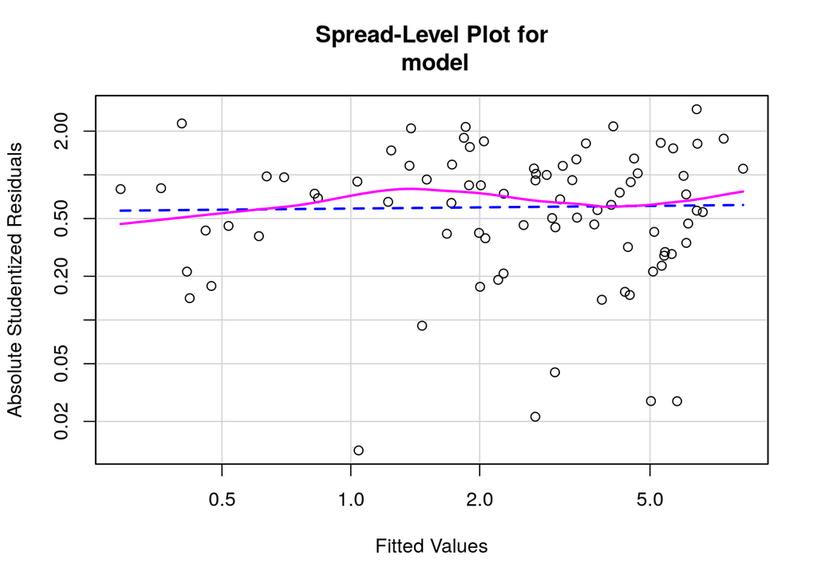

```
##
## Suggested power transformation:  0.9733684
```

Nonlinearity test:

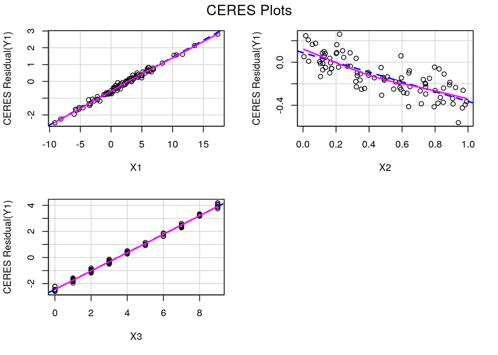

So all the factors are linear which is required.

Non-independence of Errors:

```
##  lag Autocorrelation D-W Statistic p-value
##    1       -0.138871      2.271194   0.208
##  Alternative hypothesis: rho != 0
```